# Día 3: Esperanza de vida saludable y descomposición por pasos

Autor/a

José Manuel Aburto y Ana Cristina Gómez Ugarte Valerio

Fecha de publicación

31 de diciembre de 2025

En esta práctica trabajaremos con dos tareas:

1. Estimar la esperanza de vida saludable con el método de Sullivan.
2. Descomponer sus cambios mediante el algoritmo de *stepwise replacement*.

El archivo `sullivan-stepwise-data.RData` contiene tasas de mortalidad de la [Human Mortality Database](https://www.mortality.org/) y la proporción de personas con limitaciones en sus actividades, procedente de EU-SILC y distribuida por [EurOHex](https://www.eurohex.eu/), para España y la República Checa.

## 1. Preparación

```r
load("sullivan-stepwise-data.RData")

library(tidyverse)
library(viridis)
```

Exploremos la estructura y las primeras observaciones.

```r
glimpse(data)
```

```
Rows: 96
Columns: 11
$ country    <chr> "Spain", "Spain", "Spain", "Spain", "Spain", "Spain", "Spai…
$ year       <dbl> 2010, 2010, 2010, 2010, 2010, 2010, 2010, 2010, 2011, 2011,…
$ age        <chr> "50-54", "55-59", "60-64", "65-69", "70-74", "75-79", "80-8…
$ mx         <dbl> 0.0020300, 0.0029500, 0.0039500, 0.0061500, 0.0110500, 0.02…
$ qx         <dbl> 0.010098749, 0.014642015, 0.019556876, 0.030284378, 0.05376…
$ ax         <dbl> 2.5, 2.5, 2.5, 2.5, 2.5, 2.5, 2.5, 0.5, 2.5, 2.5, 2.5, 2.5,…
$ lx         <dbl> 97885.99, 96897.47, 95478.69, 93611.43, 90776.46, 85895.89,…
$ dx         <dbl> 988.5260, 1418.7742, 1867.2649, 2834.9638, 4880.5737, 8816.…
$ Lx         <dbl> 486958.6, 480940.4, 472725.3, 460969.7, 441680.9, 407437.1,…
$ ex         <dbl> 36.594223, 31.942044, 27.379541, 22.875813, 18.512153, 14.4…
$ prevalence <dbl> 0.233, 0.299, 0.358, 0.461, 0.514, 0.609, 0.688, 0.757, 0.1…
```

```r
head(data)
```

|  | country | year | age | mx | qx | ax | lx | dx | Lx | ex | prevalence |
| --- | --- | --- | --- | --- | --- | --- | --- | --- | --- | --- | --- |
| 1 | Spain | 2010 | 50-54 | 0.00203 | 0.01009875 | 2.5 | 97885.99 | 988.526 | 486958.6 | 36.59422 | 0.233 |
| 2 | Spain | 2010 | 55-59 | 0.00295 | 0.01464202 | 2.5 | 96897.47 | 1418.774 | 480940.4 | 31.94204 | 0.299 |
| 3 | Spain | 2010 | 60-64 | 0.00395 | 0.01955688 | 2.5 | 95478.69 | 1867.265 | 472725.3 | 27.37954 | 0.358 |
| 4 | Spain | 2010 | 65-69 | 0.00615 | 0.03028438 | 2.5 | 93611.43 | 2834.964 | 460969.7 | 22.87581 | 0.461 |
| 5 | Spain | 2010 | 70-74 | 0.01105 | 0.05376475 | 2.5 | 90776.46 | 4880.574 | 441680.9 | 18.51215 | 0.514 |
| 6 | Spain | 2010 | 75-79 | 0.02164 | 0.10264681 | 2.5 | 85895.89 | 8816.939 | 407437.1 | 14.42196 | 0.609 |

## 2. Esperanza de vida saludable con el método de Sullivan

$$L_x^{saludable} = L_x(1-\pi_x).$$

Calculamos después los años saludables acumulados y la esperanza de vida saludable:

$$T_x^{saludable} = \sum_{a=x}^{\omega} L_a^{saludable},
\qquad
e_x^{saludable} = \frac{T_x^{saludable}}{\ell_x}.$$

```r
data <- data %>%
  mutate(Lx_healthy = Lx * (1 - prevalence)) %>%
  group_by(year, country) %>%
  mutate(
    Tx_healthy = rev(cumsum(rev(Lx_healthy))),
    ex_healthy = Tx_healthy / lx
  ) %>%
  ungroup()
```

Analicemos la esperanza de vida saludable a los 50 años.

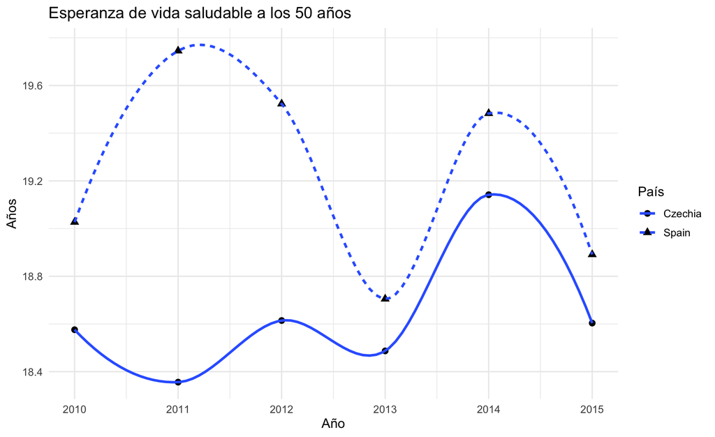

```r
data %>%
  filter(age == "50-54") %>%
  ggplot(aes(x = year, y = ex_healthy, shape = country, linetype = country)) +
  geom_point(size = 2.5) +
  geom_smooth(se = FALSE) +
  labs(
    title = "Esperanza de vida saludable a los 50 años",
    x = "Año",
    y = "Años",
    shape = "País",
    linetype = "País"
  ) +
  theme_minimal(base_size = 12)
```

**Preguntas:**

- ¿Cómo cambia la esperanza de vida saludable entre 2010 y 2015?
- ¿Qué diferencias observan entre España y la República Checa?

Comparemos ahora la esperanza de vida total y la saludable.

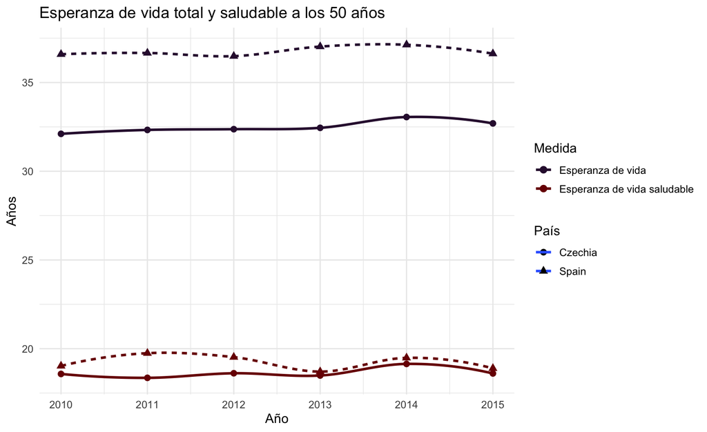

```r
data_ex <- data %>%
  pivot_longer(
    cols = c(ex, ex_healthy),
    names_to = "measure",
    values_to = "years"
  ) %>%
  mutate(
    measure = recode(
      measure,
      ex = "Esperanza de vida",
      ex_healthy = "Esperanza de vida saludable"
    )
  )

data_ex %>%
  filter(age == "50-54") %>%
  ggplot(
    aes(
      x = year,
      y = years,
      colour = measure,
      shape = country,
      linetype = country
    )
  ) +
  geom_point(size = 2.5) +
  geom_smooth(se = FALSE) +
  scale_colour_viridis_d(option = "H") +
  labs(
    title = "Esperanza de vida total y saludable a los 50 años",
    x = "Año",
    y = "Años",
    colour = "Medida",
    shape = "País",
    linetype = "País"
  ) +
  theme_minimal(base_size = 12)
```

**Pregunta:** ¿cuál es la diferencia entre la esperanza de vida total y la esperanza de vida saludable?

Otra forma de comparar ambas medidas es expresar la esperanza de vida saludable como porcentaje de la esperanza de vida total.

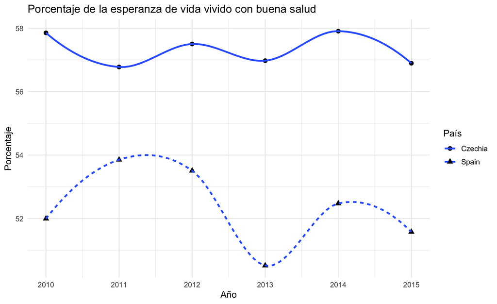

```r
data %>%
  mutate(prop_healthy = 100 * ex_healthy / ex) %>%
  filter(age == "50-54") %>%
  ggplot(
    aes(
      x = year,
      y = prop_healthy,
      shape = country,
      linetype = country
    )
  ) +
  geom_point(size = 2.5) +
  geom_smooth(se = FALSE) +
  labs(
    title = "Porcentaje de la esperanza de vida vivido con buena salud",
    x = "Año",
    y = "Porcentaje",
    shape = "País",
    linetype = "País"
  ) +
  theme_minimal(base_size = 12)
```

## 3. Descomposición mediante *stepwise replacement*

Aplicaremos el algoritmo de Andreev, Shkolnikov y Begun (2002) para descomponer el cambio en la esperanza de vida saludable. La función `funciones-sullivan-stepwise.R` calcula el indicador resumido a partir de las tasas de mortalidad y las prevalencias específicas por edad.

```r
source("funciones-sullivan-stepwise.R")
library(DemoDecomp)
```

Descompondremos el cambio entre 2010 y 2015 para las mujeres españolas. Primero construimos un vector con las tasas de mortalidad y las prevalencias de cada año. Es importante mantener el mismo orden en ambos vectores.

```r
mx1 <- data %>%
  filter(country == "Spain", year == 2010) %>%
  pull(mx)

pi1 <- data %>%
  filter(country == "Spain", year == 2010) %>%
  pull(prevalence)

mx_pi_1 <- c(mx1, pi1)

mx2 <- data %>%
  filter(country == "Spain", year == 2015) %>%
  pull(mx)

pi2 <- data %>%
  filter(country == "Spain", year == 2015) %>%
  pull(prevalence)

mx_pi_2 <- c(mx2, pi2)
```

Aplicamos el algoritmo de descomposición.

```r
ages <- seq(50, 85, 5)

results <- stepwise_replacement(
  func = healthy_ex,
  pars1 = mx_pi_1,
  pars2 = mx_pi_2,
  age = ages,
  symmetrical = TRUE,
  direction = "up"
)

results
```

```
 [1]  0.005958603 -0.006013845 -0.007062679  0.004696075  0.022012115
 [6]  0.023881057  0.012462404 -0.034929288  0.069652608  0.039308657
[11] -0.038626142  0.207157339  0.257467518 -0.167210805 -0.082135148
[16] -0.442556281
```

Verifiquemos que la suma de las contribuciones coincide con la diferencia original.

```r
original <- healthy_ex(mx_pi_2, age = ages) -
  healthy_ex(mx_pi_1, age = ages)

with_decomp <- sum(results)

tibble(
  estimacion = c("Diferencia original", "Suma de contribuciones"),
  valor = c(original, with_decomp)
)
```

| estimacion | valor |
| --- | --- |
| Diferencia original | -0.1359378 |
| Suma de contribuciones | -0.1359378 |

Separamos las contribuciones de la mortalidad y de la prevalencia para interpretarlas por grupo de edad.

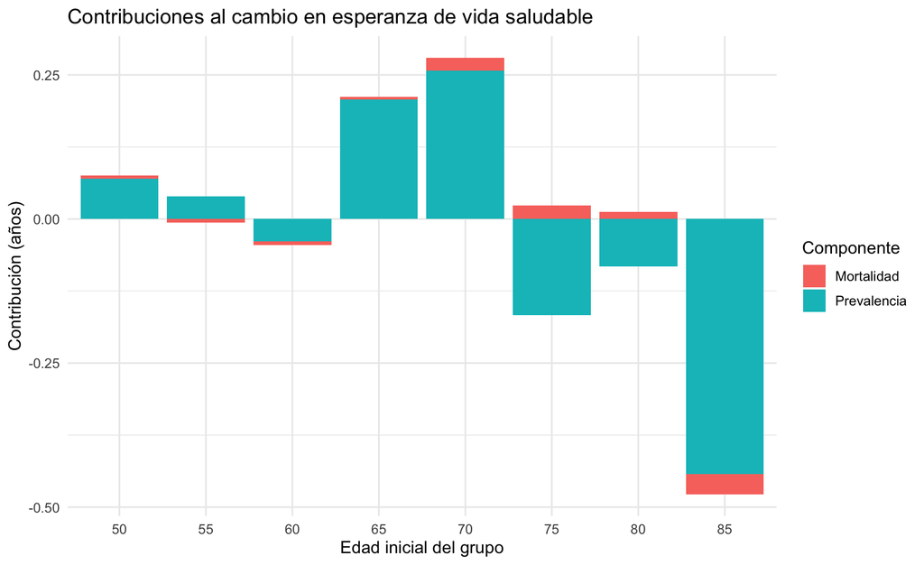

```r
n_ages <- length(results) / 2

contr_results <- tibble(
  age = ages,
  Mortalidad = results[seq_len(n_ages)],
  Prevalencia = results[n_ages + seq_len(n_ages)]
) %>%
  pivot_longer(
    cols = c(Mortalidad, Prevalencia),
    names_to = "componente",
    values_to = "contribucion"
  )

contr_results %>%
  ggplot(aes(x = factor(age), y = contribucion, fill = componente)) +
  geom_col() +
  labs(
    title = "Contribuciones al cambio en esperanza de vida saludable",
    x = "Edad inicial del grupo",
    y = "Contribución (años)",
    fill = "Componente"
  ) +
  theme_minimal(base_size = 12)
```

## 4. Ejercicio

Descompongan la diferencia en la esperanza de vida saludable entre las mujeres de España y las mujeres de la República Checa en 2010.

**Preguntas:**

- ¿Qué componente tiene mayor efecto: la mortalidad o la prevalencia?
- ¿En qué grupos de edad se concentran las contribuciones?
- ¿La suma de las contribuciones reproduce la diferencia original?

## Referencia

Andreev, E. M., Shkolnikov, V. M. y Begun, A. Z. (2002). Algorithm for decomposition of differences between aggregate demographic measures and its application to life expectancies, healthy life expectancies, parity-progression ratios and total fertility rates. *Demographic Research*, 7, 499-522.